# Scraping BBC Food Recipes

Dominik Gulacsy

2020-12-15

## Intro

I used [**BBC Food**](https://www.bbc.co.uk/food) as a target site for this webscraping project. I opted for this site because it’s content for me was relevant. Actually I am interested in creating a recipe gatherer and an app that can easily show the steps of the cooking on a tablet, can make recommendations on dietary and scheduling preferences (e.g: gluten-free, batch cooking) and has the feature to show recipe suggestion when uploading a picture of ingredients by calculating ingredient similarity scores. With a built-in ingredient stock (resource) manager which predicts based on consumption habits when certain ingredients will get low. Regarding technicalities the basic structure of site was easy to understand and made the scraping process relatively clear. Yet there was some JSONs that could be extracted to make the process much more manageable and long-life.

## Step-by-step description of my webscraping script

Note: I used the following libraries to write the script:

```
library(rvest)
library(selectr)
library(prettydoc)
library(dplyr)
library(data.table)
```

1. Overview While investigating the site’s structure I recognized that recipes are organized on the site in the following way:
2. A-Z indexing “https://www.bbc.co.uk/food/recipes/a-z/a/1#featured-content”

[figure not shown]

3. Pagination “https://www.bbc.co.uk/food/recipes/a-z/b/7#featured-content”

[figure not shown]

4. Recipe sites “https://www.bbc.co.uk/food/recipes/aclassicspongecakewi_9406”

[figure not shown]

This structure represents the core logic behind my script. So firstly, I should get the initial letter pages, then the paginated pages an lastly all the recipe pages listed on the before mentioned pages.

2. Getting the JSONs Going through the Network tab in Google Chrome I found that all of these page types contain a JSON in their HTML doc.

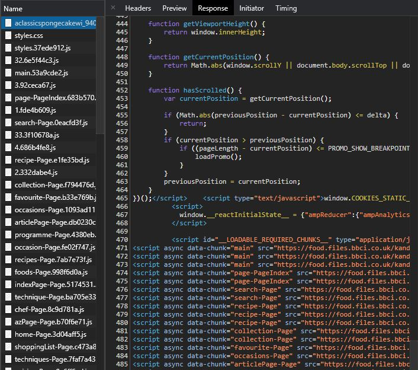

’’

However, getting this JSON is not that easy it may look since there is no id or class associated with the script tag that contains the JSON. So in order to properly extract these JSONs I had to use a function that can look for the `window.__reactInitialState__ =` expression among the script tags and return the JSON of the one that includes it.

```r
# Create function to extract JSON from the HTML Doc
get_json_values <- function(my_page , my_look_for, ful_name) {
  #my_look_for <- 'reactInitialState'
  #ful_name <- 'window.__reactInitialState__ = '
  script_list <-
    my_page %>%
    html_nodes("script")

  for (i in script_list) {
    my_t <- i %>%
      html_text()
    my_t_h <- substring(my_t, 1,100)
    #print(my_t)
    if(grepl(my_look_for, my_t_h)){
      res <- substring(str_trim(my_t), nchar(ful_name)+1)
      res <- gsub('\\</b>', '',gsub('\\<b>', '', gsub('}};', '}}', res, fixed = T), fixed = T), fixed = T)
      return(fromJSON(res))
    }
  }
}
```

We can get the necessary data this way on every level. Actually, I needed to get the one JSON to know what are the initial letter indexes and get the JSON for every page and every recipe.

To further develop my script I retrieve the JSON from “https://www.bbc.co.uk/food/recipes/a-z/a/1#featured-content” which contains the data on initial letters and the URLs for the recipe pages in azPageReducer item.

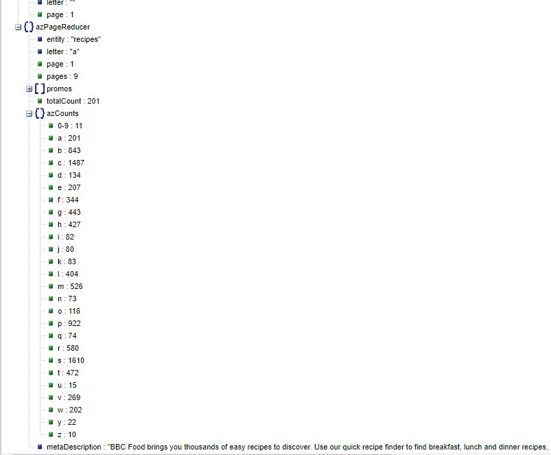

’’

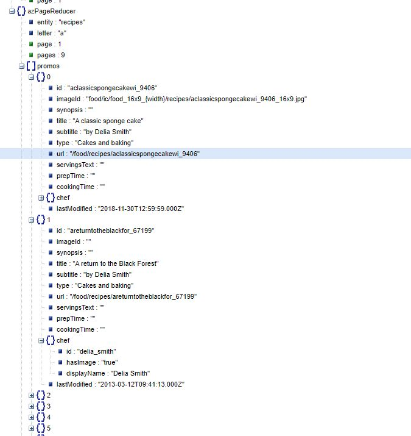

’’

Then I also extracted the JSON from “https://www.bbc.co.uk/food/recipes/aclassicspongecakewi_9406” just to see what kind of data can be collected from the page. I decided to collect the recipe category, title, description, some diet labels, collection label, chef, preparation time, cook time, food name, number of ratings and rating score. Plus the ingredients, stages, instructions and occasion labels as lists too.

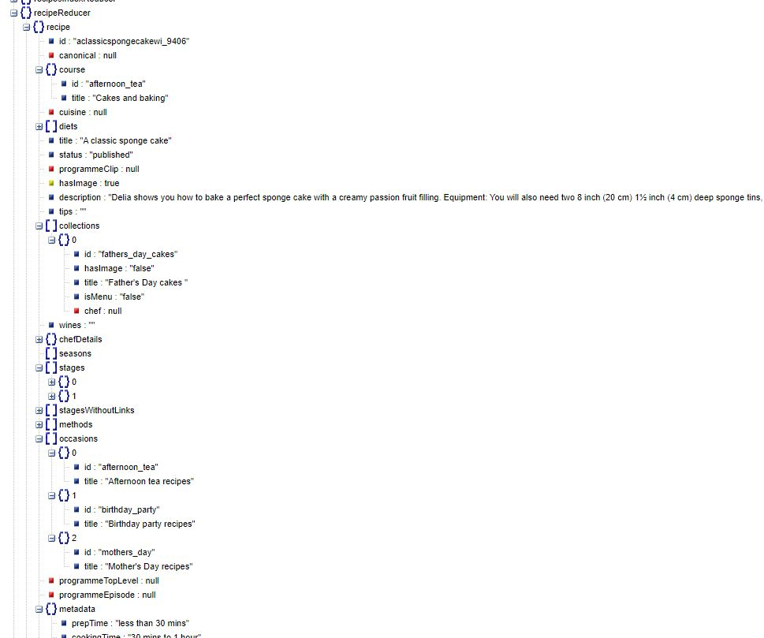

’’

3. Getting the ingredients from the JSON Getting the ingredients from the JSON was not easy as they were embedded in the stage items. So I needed to consolidate all ingredients from all stages of the recipe to have the whole list of ingredients.

```r
# Create function to get ingredients from nested lists
get_ingredients <- function() {
  stages<-recipe_json$recipeReducer$recipe$stagesWithoutLinks
  ing <- c()
  for (stage in 1:length(stages)){
    for (aux in 1:length(stages[stage,"ingredients"])){
      for (ingredient in 1:length(stages[stage,"ingredients"][[aux]]$foods)){
        ing <- c(ing,stages[stage,"ingredients"][[aux]]$foods[[ingredient]]$title)
      }
    }
  }
  return(ing)
}
```

4. Handling missing values Later on during the collection of recipes I realized that I needed a mechanism to check if a list was empty and return with NA if so. Thus I wrote the following function and created an other to check if items are being NULL:

```r
# Create function that returns NA when list is empty and with element if not
get_if_not_empty <- function(list,row,col) {
  if (is_empty(list)){
    return(NA)
  } else{
    return(list[row,col])
  }
}

# Create function that returns NA when item is null and with itself if not
get_if_not_null <- function(item) {
  if (is_null(item)) {
    return(NA)
  } else{
    return(item)
  }
}
```

5. Initializing the automatized scraper To get ready to scrape all recipe pages, I got the initial letter indexes from the above mentioned JSON and saved it into a variable. I created a data frame for the variables intended to be scraped and empty lists for the ingredients, stages, instructions and occasion labels.

```r
# Find BBC Food page to get letter page letters
t <- read_html('https://www.bbc.co.uk/food/recipes/a-z/a/1#featured-content')
write_html(t, paste0(path, "bbc_food_page.html"))
d <- "https://www.bbc.co.uk"

init_json <- get_json_values(t, 'reactInitialState', 'window.__reactInitialState__ = ')
letters<- names(init_json$azPageReducer$azCounts)

# Initialize output table

df<-data.frame(
  "category"= character(),
  "title"= character(),
  "description"= character(),
  "diet1" = character(),
  "diet2" = character(),
  "diet3" = character(),
  "collection" = character(),
  "chef" = character(),
  "prep_time" = character(),
  "cook_time" = character(),
  "food" = character(),
  "rating_no" = numeric(),
  "rating_val" = numeric()
)

stages <- list()
ingredients <- list()
instructions <- list()
occasions <- list()
```

6. Running the Automated Scraper My script gets the data from the BBC Food site using 3 for loops. This inherently comes from the structure of the site discussed in the overview section. The first loop gets the letter sites by plugging the letters in the URL. The second loop gets the site for every page by plugging in the max page based on the initial letter. Finally the last loop gets all recipe pages that are listed on the pages. The scraper also archives the HTML document in a corresponding folder structure which is created on the fly. Each set of values is added as a row recipe by recipe to the “df” data frame. Eventually the collected list elements are also appended to the data frame as columns.
7. Adding derived variables To gain more insight using this data, I also added the following calculated columns: number of stages, number of ingredients, number of instructions, number of occasions.

```r
df$no_stages <- unlist(lapply(df$stages,length))
df$no_ingredients <- unlist(lapply(df$ingredients,length))
df$no_instructions <- unlist(lapply(df$instructions,length))
df$no_occasions <- unlist(lapply(df$occasions,length))
```

## Explanatory Data Analysis

1. Rating distribution Firstly, I looked at how the rating of recipes is distributed. It looks like there are very few number of recipes that have more than 50 ratings. So in many cases the true quality of the recipe cannot be evaluated. However, it can be seen that when users indeed rate the recipe they usually rate it good. Most recipes have an above 4 rating.

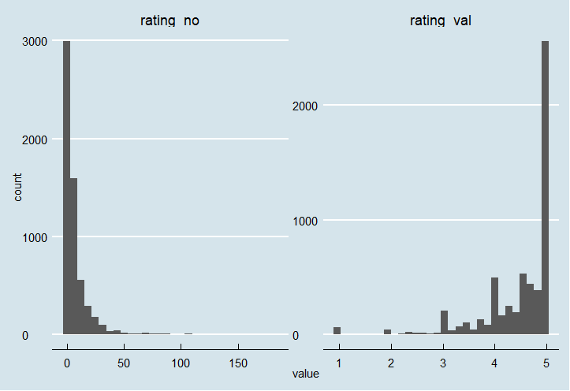

’’

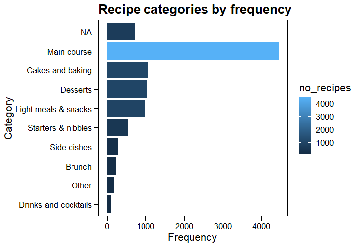

’’

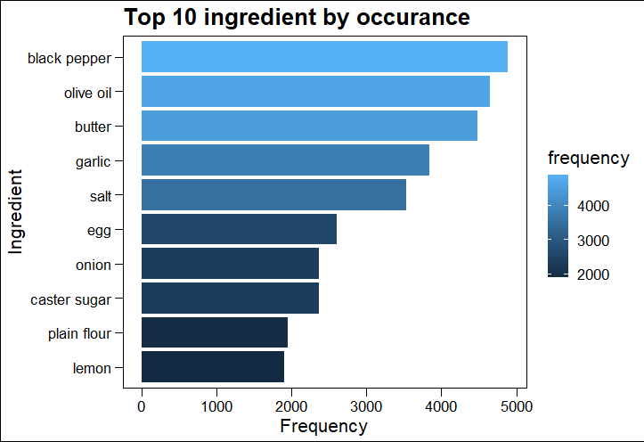

’’

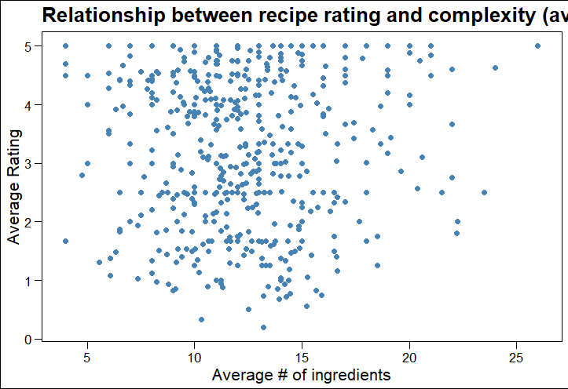

’’